# ImplementationPerceptron

**Explanation of the intuition behind the Perceptron algorithm.**

The perceptron algorithm is a supervised learning used for binary clasification. Is is a type of linear classifier that makes its predictions based on a linear predictor function combining a set of weights with the feature vector. The algorithm was invented in 1943 by warren McCullioch and Walter Pitts. Is a type of a neural network model, perhaps the simplest type of neural model. It consists of a single node or neuron tha takes a now of data as input an predicts a class label.

The intuition behind the perceptron algorithm is to find the optimal hyperplane that separates the two classes in the feature space. The algorithm starts with random weights and iteratively updates them until convergence. During each iteration, the algorithm computes the dot product between the feature vector and the weight vector and applies an activation function to obtain the predicted class label. If the predicted label is incorrect, the algorithm updates the weights to move the hyperplane closer to the correct label.

To understand how the perceptron algorithm works, it is helpful to think about it geometrically. Each data point in the training set can be represented as a point in a multidimensional space, where each dimension represents a feature of the data point. The weights of the perceptron algorithm can be represented as a vector in the same multidimensional space.

The perceptron algorithm works by finding a vector that is orthogonal to the hyperplane that separates the data points into two categories. This vector is known as the normal vector to the hyperplane. The perceptron algorithm does this by iteratively adjusting the weights of the perceptron until the normal vector to the hyperplane points in the direction that minimizes the number of misclassified points.

Once the perceptron algorithm has found a set of weights that results in a hyperplane that correctly classifies all of the data points in the training set, the perceptron can be used to classify new data points. To classify a new data point, the perceptron simply calculates the dot product of the new data point and the weights of the perceptron. If the dot product is positive, the perceptron classifies the new data point as belonging to the first category. If the dot product is negative, the perceptron classifies the new data point as belonging to the second category.

We can represent schematically a perceptron as :

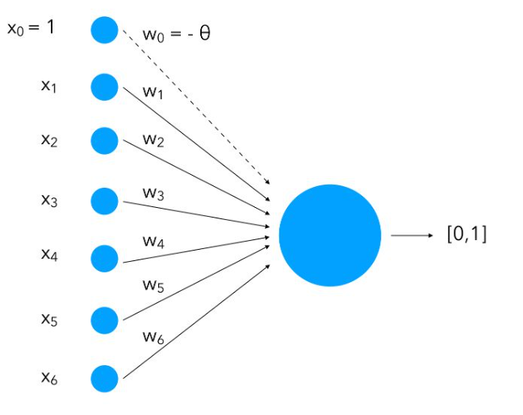

The perceptron algorithm is a very simple algorithm, but it can be used to solve a wide variety of machine learning problems. For example, the perceptron algorithm can be used to classify images, classify text, and predict customer behavior.

**What is the activation function used in perceptron?**

The most commonly used activation function in a perceptron is the unit step function or Heaviside function. It returns if the weighted sum of inputs is greater that or equal to zero, and 0 otherwise. Another common activation function used in perceptron is the sign function, which returns -1 if the wighted sum of inputs is negative, 0 if it is zero, and 1 if it is positive.

**Pseudocode of the algorithm**

*Input:*

*X: A training set of data points, where each data point is a vector of features.*

*y: A training set of labels, where each label is either 1 or -1. learning_rate: A learning rate parameter.*

*Initialize the weights of the perceptron randomly.* w = random()

*Repeat until the perceptron converges:* for x in X:

```
# Calculate the predicted output of the perceptron.
y_pred = w.dot(x)

# If the predicted output is different from the actual output, update the weights of the perceptron.
if y_pred != y:
    w += learning_rate * (y - y_pred) * x
```

*Return the trained weights of the perceptron.*

*return w*

To use the perceptron algorithm to classify a new data point, we simply calculate the dot product of the new data point and the weights of the perceptron. If the dot product is positive, we classify the new data point as belonging to the first category. If the dot product is negative, we classify the new data point as belonging to the second category.

For example, suppose that we have trained a perceptron to classify images of cats and dogs. To classify a new image, we would simply calculate the dot product of the new image vector and the weights of the perceptron. If the dot product is positive, we would classify the new image as a cat. If the dot product is negative, we would classify the new image as a dog.

The perceptron algorithm is a very simple algorithm, but it is effective for solving a wide variety of machine learning problems. It is also a good starting point for understanding more complex machine learning algorithms, such as deep neural networks.

**Algorithm of perceptron**

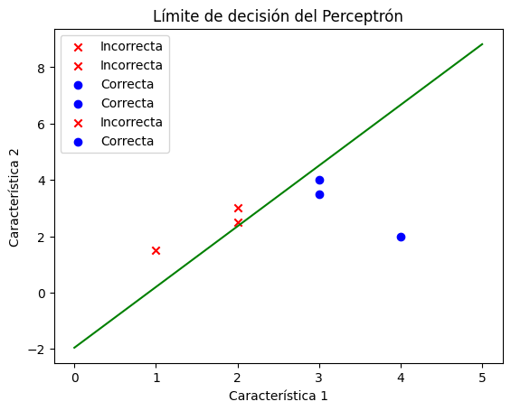

```python
import numpy as np
import matplotlib.pyplot as plt

# Datos de entrada (características)
X = np.array([[2, 3], [1, 1.5], [4, 2], [3, 4], [2, 2.5], [3, 3.5]])
# Etiquetas de clase (0 o 1)
y = np.array([0, 0, 1, 1, 0, 1])

# Inicialización de pesos y sesgo
weights = np.random.rand(2)
bias = np.random.rand(1)

# Tasa de aprendizaje (learning rate)
learning_rate = 0.1

# Función de activación (en este caso, una función escalón)
def activation_function(z):
    if z >= 0:
        return 1
    else:
        return 0

# Listas para almacenar las predicciones
predictions = []

# Entrenamiento del perceptrón
for _ in range(100):
    for i in range(len(X)):
        # Calcular la salida del perceptrón
        z = np.dot(X[i], weights) + bias
        y_pred = activation_function(z)
        predictions.append(y_pred)

        # Actualizar los pesos y el sesgo
        error = y[i] - y_pred
        weights += learning_rate * error * X[i]
        bias += learning_rate * error

# Plotear los puntos de datos con colores diferentes para las predicciones correctas e incorrectas
for i in range(len(X)):
    if y[i] == predictions[i]:
        plt.scatter(X[i, 0], X[i, 1], c='b', marker='o', label='Correcta')
    else:
        plt.scatter(X[i, 0], X[i, 1], c='r', marker='x', label='Incorrecta')

# Dibujar el límite de decisión
x_boundary = np.array([0, 5])
y_boundary = (-1 / weights[1]) * (weights[0] * x_boundary + bias)
plt.plot(x_boundary, y_boundary, 'g-')

plt.xlabel('Característica 1')
plt.ylabel('Característica 2')
plt.title('Límite de decisión del Perceptrón')
plt.legend()
plt.show()
```

**Loss function + Optimization function**

The code implements a simple perceptron with a step activation function to perform a binary classification. However, it does not include a loss function or an optimization function. Instead, a basic learning rule is used that adjusts the weights and bias of the perceptron as a function of the classification error.

Loss and optimization functions are common components in more advanced supervised learning algorithms, such as deep neural networks. The loss function is used to evaluate how well the model fits the data, and the optimization function is responsible for adjusting model parameters (such as weights and biases) to minimize loss. These functions are essential in the neural network training process.

The adjustment of weights and bias is done directly as a function of the classification error, without using a specific loss function or optimization algorithm. This approach is valid for a simple perceptron, but in more complex problems, such as training deep neural networks, more sophisticated loss functions and optimization are used.